# Geodemographic Segmentation Model for Bank Customer Churn Prediction

## What is Customer Churn?

- Customer churn or Customer Attrition refers to when a customer Ends his or her relationship with a company.
- Online businesses typically treat a customer as churned once a particular amount of time has elapsed since the customer’s last interaction with the site or service.
- The full cost of customer churn includes both lost revenue and the marketing costs involved with replacing those customers with new ones.

## Need for Customer Churn Prediction?

- The ability to predict that a particular customer is at a high risk of churning, while there is still time to do something about it, represents a huge additional potential revenue source for any business
- Besides the direct loss of revenue that results from a customer abandoning the business, the costs of initially acquiring that customer may not have already been covered by the customer’s spending to date
- Furthermore, it is always more difficult and expensive to acquire a new customer than it is to retain a current paying customer

## Customer Churn Prediction for a Banking Dataset

- A bank which is currently going through a higher churn rate which is bad for their business and they wanted to address this problem
- Given the rise in the number of customers who left the bank, the bank decided to collect data during 6 month period to evaluate the problem
- 10000 customers were selected randomly among three countries – France, Germany and Spain.

## Goal of our Model

Predict which customer is more likely to leave the bank given, how long they have been a customer of the bank, whether they are an active member, age, gender, credit score, estimated salary, number of products and if the customer has a credit card or not

### Informations Collected from Each Customers for the Past 6 Months are:

1. **Customer_ID**
2. **Surname**
3. **Credit_Score**
4. **Geography**
5. **Gender**
6. **Age**
7. **Tenure**
8. **Balance**
9. **Num_of_Product**
10. **Has_Credit_Card**
11. **Is_Active_Member**
12. **Estimated_Salary**
13. **Exited**

### Importing Required Libraries

```python
import pandas as pd
import numpy as np
import matplotlib.pyplot as plt
import seaborn as sns
import warnings
warnings.filterwarnings('ignore')
%matplotlib inline
```

```python
df=pd.read_csv('D:\\AAAA Python for Data Science\\zProjects\\Churn_Modelling.csv')
```

```python
df.head()
```

|  | RowNumber | CustomerId | Surname | CreditScore | Geography | Gender | Age | Tenure | Balance | NumOfProducts | HasCrCard | IsActiveMember | EstimatedSalary | Exited |
| --- | --- | --- | --- | --- | --- | --- | --- | --- | --- | --- | --- | --- | --- | --- |
| 0 | 1 | 15634602 | Hargrave | 619 | France | Female | 42 | 2 | 0.00 | 1 | 1 | 1 | 101348.88 | 1 |
| 1 | 2 | 15647311 | Hill | 608 | Spain | Female | 41 | 1 | 83807.86 | 1 | 0 | 1 | 112542.58 | 0 |
| 2 | 3 | 15619304 | Onio | 502 | France | Female | 42 | 8 | 159660.80 | 3 | 1 | 0 | 113931.57 | 1 |
| 3 | 4 | 15701354 | Boni | 699 | France | Female | 39 | 1 | 0.00 | 2 | 0 | 0 | 93826.63 | 0 |
| 4 | 5 | 15737888 | Mitchell | 850 | Spain | Female | 43 | 2 | 125510.82 | 1 | 1 | 1 | 79084.10 | 0 |

```python
df.tail()
```

|  | RowNumber | CustomerId | Surname | CreditScore | Geography | Gender | Age | Tenure | Balance | NumOfProducts | HasCrCard | IsActiveMember | EstimatedSalary | Exited |
| --- | --- | --- | --- | --- | --- | --- | --- | --- | --- | --- | --- | --- | --- | --- |
| 9995 | 9996 | 15606229 | Obijiaku | 771 | France | Male | 39 | 5 | 0.00 | 2 | 1 | 0 | 96270.64 | 0 |
| 9996 | 9997 | 15569892 | Johnstone | 516 | France | Male | 35 | 10 | 57369.61 | 1 | 1 | 1 | 101699.77 | 0 |
| 9997 | 9998 | 15584532 | Liu | 709 | France | Female | 36 | 7 | 0.00 | 1 | 0 | 1 | 42085.58 | 1 |
| 9998 | 9999 | 15682355 | Sabbatini | 772 | Germany | Male | 42 | 3 | 75075.31 | 2 | 1 | 0 | 92888.52 | 1 |
| 9999 | 10000 | 15628319 | Walker | 792 | France | Female | 28 | 4 | 130142.79 | 1 | 1 | 0 | 38190.78 | 0 |

```python
df.info()
```

```
<class 'pandas.core.frame.DataFrame'>
RangeIndex: 10000 entries, 0 to 9999
Data columns (total 14 columns):
RowNumber          10000 non-null int64
CustomerId         10000 non-null int64
Surname            10000 non-null object
CreditScore        10000 non-null int64
Geography          10000 non-null object
Gender             10000 non-null object
Age                10000 non-null int64
Tenure             10000 non-null int64
Balance            10000 non-null float64
NumOfProducts      10000 non-null int64
HasCrCard          10000 non-null int64
IsActiveMember     10000 non-null int64
EstimatedSalary    10000 non-null float64
Exited             10000 non-null int64
dtypes: float64(2), int64(9), object(3)
memory usage: 1.1+ MB
```

```python
df.describe()
```

|  | RowNumber | CustomerId | CreditScore | Age | Tenure | Balance | NumOfProducts | HasCrCard | IsActiveMember | EstimatedSalary | Exited |
| --- | --- | --- | --- | --- | --- | --- | --- | --- | --- | --- | --- |
| count | 10000.00000 | 1.000000e+04 | 10000.000000 | 10000.000000 | 10000.000000 | 10000.000000 | 10000.000000 | 10000.00000 | 10000.000000 | 10000.000000 | 10000.000000 |
| mean | 5000.50000 | 1.569094e+07 | 650.528800 | 38.921800 | 5.012800 | 76485.889288 | 1.530200 | 0.70550 | 0.515100 | 100090.239881 | 0.203700 |
| std | 2886.89568 | 7.193619e+04 | 96.653299 | 10.487806 | 2.892174 | 62397.405202 | 0.581654 | 0.45584 | 0.499797 | 57510.492818 | 0.402769 |
| min | 1.00000 | 1.556570e+07 | 350.000000 | 18.000000 | 0.000000 | 0.000000 | 1.000000 | 0.00000 | 0.000000 | 11.580000 | 0.000000 |
| 25% | 2500.75000 | 1.562853e+07 | 584.000000 | 32.000000 | 3.000000 | 0.000000 | 1.000000 | 0.00000 | 0.000000 | 51002.110000 | 0.000000 |
| 50% | 5000.50000 | 1.569074e+07 | 652.000000 | 37.000000 | 5.000000 | 97198.540000 | 1.000000 | 1.00000 | 1.000000 | 100193.915000 | 0.000000 |
| 75% | 7500.25000 | 1.575323e+07 | 718.000000 | 44.000000 | 7.000000 | 127644.240000 | 2.000000 | 1.00000 | 1.000000 | 149388.247500 | 0.000000 |
| max | 10000.00000 | 1.581569e+07 | 850.000000 | 92.000000 | 10.000000 | 250898.090000 | 4.000000 | 1.00000 | 1.000000 | 199992.480000 | 1.000000 |

```python
df.shape
```

```
(10000, 14)
```

```python
df.columns
```

```
Index(['RowNumber', 'CustomerId', 'Surname', 'CreditScore', 'Geography',
       'Gender', 'Age', 'Tenure', 'Balance', 'NumOfProducts', 'HasCrCard',
       'IsActiveMember', 'EstimatedSalary', 'Exited'],
      dtype='object')
```

```python
X=df.iloc[:,3:-1].values ## Excluding row_num,Cust_id,Surname since it doesn't have any impact to our Prediction
y=df.iloc[:,-1].values
```

```python
X.shape
```

```
(10000, 10)
```

```python
y
```

```
array([1, 0, 1, ..., 1, 1, 0], dtype=int64)
```

## Exploratory Data Analysis Using Graphs

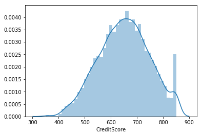

```python
credit_score=sns.distplot(df['CreditScore'])
```

```python
no_of_country=df['Geography'].value_counts()
```

```python
no_of_country
```

```
France     5014
Germany    2509
Spain      2477
Name: Geography, dtype: int64
```

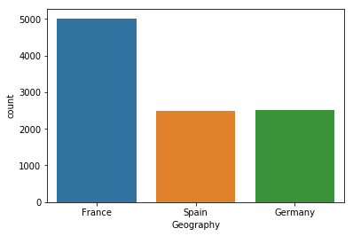

```python
sns.countplot(x='Geography',data=df)
```

```python
gender=df['Gender'].value_counts()
```

```python
gender
```

```
Male      5457
Female    4543
Name: Gender, dtype: int64
```

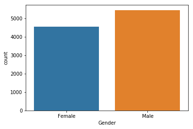

```python
sns.countplot(x='Gender',data=df)
```

```python
exited=df['Exited'].value_counts()
```

```python
exited
```

```
0    7963
1    2037
Name: Exited, dtype: int64
```

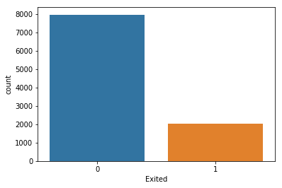

```python
sns.countplot(x='Exited',data=df)
```

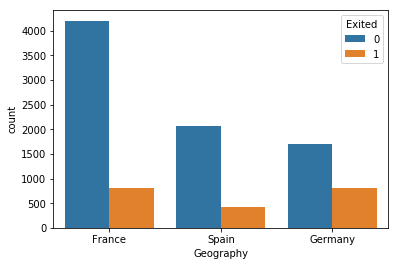

```python
sns.countplot(x='Geography',hue='Exited',data=df)
```

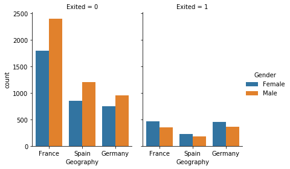

```python
sns.catplot(x='Geography', hue='Gender', col='Exited',data=df, kind="count",height=4, aspect=.7);
```

### Insight: As far as Country and Gender is concerned Female customers from France and germany have exited more than spain.

```python
age=df['Age'].mean()
```

```python
age
```

```
38.9218
```

```python
age
```

```
38.9218
```

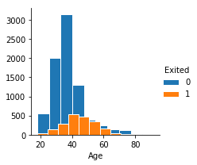

```python
age_graph= sns.FacetGrid(df,hue = 'Exited')
(age_graph.map(plt.hist,'Age',edgecolor="w").add_legend())
```

### Insight: As far as Age is concerned customers whose Age ranging from 40-50 have exited more.

```python
df['Tenure'].mean()
```

```
5.0128
```

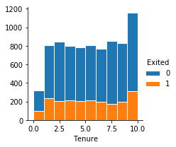

```python
tenure_graph=sns.FacetGrid(df,hue='Exited')
(tenure_graph.map(plt.hist,'Tenure',edgecolor='w').add_legend())
```

### Insight: The Average Tenure of a Customer is 5 years and from the Graph we can see that the Customer with Maximum Tenure have Exited

```python
df['Balance'].mean()
```

```
76485.88928799961
```

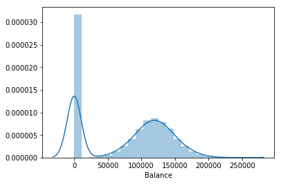

```python
balance_graph=sns.distplot(df['Balance'])
```

```python
zero_bal=(df['Balance'] == 0).value_counts()
```

```python
zero_bal
```

```
False    6383
True     3617
Name: Balance, dtype: int64
```

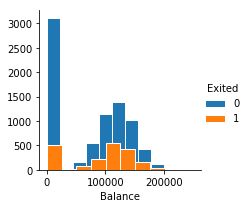

```python
zero_bal=sns.FacetGrid(df,hue='Exited')
(zero_bal.map(plt.hist,'Balance',edgecolor='w').add_legend())
```

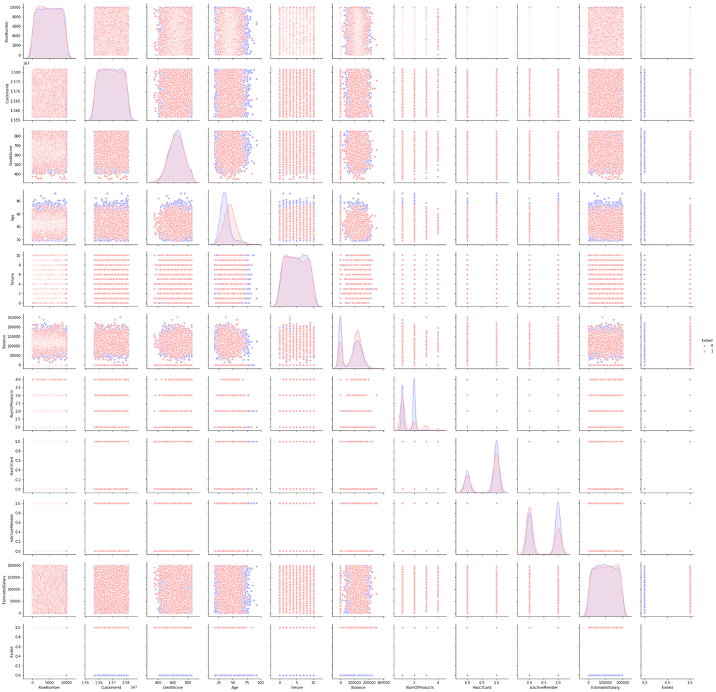

```python
sns.pairplot(df,hue='Exited',palette='bwr')
```

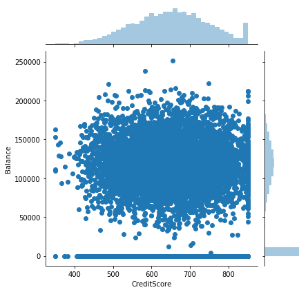

```python
sns.jointplot(x='CreditScore',y='Balance',data=df)
```

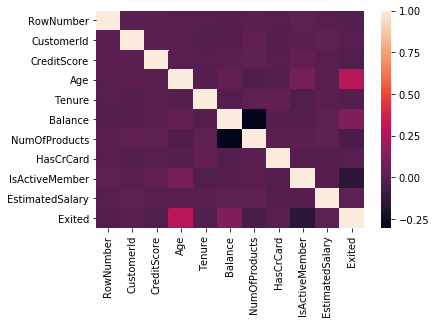

```python
sns.heatmap(df.corr())
```

## Data Preprocessing

```python
from sklearn.preprocessing import LabelEncoder
```

```python
country_lab_enc=LabelEncoder()
```

```python
X[:,1]=country_lab_enc.fit_transform(X[:,1])
```

```python
gender_lab_enc=LabelEncoder()
```

```python
X[:,2]=gender_lab_enc.fit_transform(X[:,2])
```

```python
X[:,1]
```

```
array([0, 2, 0, ..., 0, 1, 0], dtype=object)
```

```python
X[:,2]
```

```
array([0, 0, 0, ..., 0, 1, 0], dtype=object)
```

```python
X
```

```
array([[619, 0, 0, ..., 1, 1, 101348.88],
       [608, 2, 0, ..., 0, 1, 112542.58],
       [502, 0, 0, ..., 1, 0, 113931.57],
       ...,
       [709, 0, 0, ..., 0, 1, 42085.58],
       [772, 1, 1, ..., 1, 0, 92888.52],
       [792, 0, 0, ..., 1, 0, 38190.78]], dtype=object)
```

```python
from sklearn.preprocessing import OneHotEncoder
```

```python
one_hot_enc=OneHotEncoder(categorical_features=[1])
```

```python
X=one_hot_enc.fit_transform(X).toarray()
```

```
C:\Users\Ashwin kumar\Anaconda3\anacondathree\lib\site-packages\sklearn\preprocessing\_encoders.py:392: DeprecationWarning: The 'categorical_features' keyword is deprecated in version 0.20 and will be removed in 0.22. You can use the ColumnTransformer instead.
  "use the ColumnTransformer instead.", DeprecationWarning)
```

```python
X=pd.DataFrame(X)
```

```python
X.info()
```

```
<class 'pandas.core.frame.DataFrame'>
RangeIndex: 10000 entries, 0 to 9999
Data columns (total 12 columns):
0     10000 non-null float64
1     10000 non-null float64
2     10000 non-null float64
3     10000 non-null float64
4     10000 non-null float64
5     10000 non-null float64
6     10000 non-null float64
7     10000 non-null float64
8     10000 non-null float64
9     10000 non-null float64
10    10000 non-null float64
11    10000 non-null float64
dtypes: float64(12)
memory usage: 937.6 KB
```

## Train,Test Split

```python
from sklearn.model_selection import train_test_split
```

```python
X_train,X_test,y_train,y_test=train_test_split(X,y,test_size=0.3,random_state=42)
```

## Logistic Regression

```python
from sklearn.linear_model import LogisticRegression
```

```python
log_model=LogisticRegression()
```

```python
log_model.fit(X_train,y_train)
```

```
LogisticRegression(C=1.0, class_weight=None, dual=False, fit_intercept=True,
          intercept_scaling=1, max_iter=100, multi_class='warn',
          n_jobs=None, penalty='l2', random_state=None, solver='warn',
          tol=0.0001, verbose=0, warm_start=False)
```

## Model Prediction

```python
predictions=log_model.predict(X_test)
```

## Classification Report

```python
from sklearn.metrics import classification_report
```

```python
print(classification_report(y_test,predictions))
```

```
              precision    recall  f1-score   support

           0       0.82      0.97      0.89      2416
           1       0.43      0.09      0.15       584

   micro avg       0.80      0.80      0.80      3000
   macro avg       0.62      0.53      0.52      3000
weighted avg       0.74      0.80      0.74      3000
```

## Decision Trees

```python
from sklearn.tree import DecisionTreeClassifier
dtree = DecisionTreeClassifier()
dtree.fit(X_train,y_train)
```

```
DecisionTreeClassifier(class_weight=None, criterion='gini', max_depth=None,
            max_features=None, max_leaf_nodes=None,
            min_impurity_decrease=0.0, min_impurity_split=None,
            min_samples_leaf=1, min_samples_split=2,
            min_weight_fraction_leaf=0.0, presort=False, random_state=None,
            splitter='best')
```

## Model Prediction

```python
predictions=dtree.predict(X_test)
```

## Classification Report

```python
from sklearn.metrics import classification_report,confusion_matrix
print(classification_report(y_test,predictions))
```

```
              precision    recall  f1-score   support

           0       0.88      0.87      0.88      2416
           1       0.50      0.52      0.51       584

   micro avg       0.81      0.81      0.81      3000
   macro avg       0.69      0.70      0.70      3000
weighted avg       0.81      0.81      0.81      3000
```

## Random Forest

```python
from sklearn.ensemble import RandomForestClassifier
rfc = RandomForestClassifier(n_estimators=100)
rfc.fit(X_train, y_train)
```

```
RandomForestClassifier(bootstrap=True, class_weight=None, criterion='gini',
            max_depth=None, max_features='auto', max_leaf_nodes=None,
            min_impurity_decrease=0.0, min_impurity_split=None,
            min_samples_leaf=1, min_samples_split=2,
            min_weight_fraction_leaf=0.0, n_estimators=100, n_jobs=None,
            oob_score=False, random_state=None, verbose=0,
            warm_start=False)
```

## Model Prediction

```python
rfc_pred = rfc.predict(X_test)
print(confusion_matrix(y_test,rfc_pred))
```

```
[[2340   76]
 [ 312  272]]
```

## Classification Report

```python
print(classification_report(y_test,rfc_pred))
```

```
              precision    recall  f1-score   support

           0       0.88      0.97      0.92      2416
           1       0.78      0.47      0.58       584

   micro avg       0.87      0.87      0.87      3000
   macro avg       0.83      0.72      0.75      3000
weighted avg       0.86      0.87      0.86      3000
```

## KNN CLASSIFIER MODEL

```python
from sklearn.neighbors import KNeighborsClassifier
knn=KNeighborsClassifier(n_neighbors=12)
knn.fit(X_train,y_train)
```

```
KNeighborsClassifier(algorithm='auto', leaf_size=30, metric='minkowski',
           metric_params=None, n_jobs=None, n_neighbors=12, p=2,
           weights='uniform')
```

## Model Prediction

```python
pred = knn.predict(X_test)
```

## Classification Report

```python
print(confusion_matrix(y_test,pred))
print(classification_report(y_test,pred))
```

```
[[2391   25]
 [ 574   10]]
              precision    recall  f1-score   support

           0       0.81      0.99      0.89      2416
           1       0.29      0.02      0.03       584

   micro avg       0.80      0.80      0.80      3000
   macro avg       0.55      0.50      0.46      3000
weighted avg       0.71      0.80      0.72      3000
```

### Using Deep Neural Network

```python
from sklearn.preprocessing import StandardScaler
std_scl=StandardScaler()
X_train=std_scl.fit_transform(X_train)
X_test=std_scl.transform(X_test)
```

```python
X_train.shape
```

```
(7000, 12)
```

```python
import keras
from keras.models import Sequential
from keras.layers import Dense
from keras.layers import Dropout
import warnings
warnings.filterwarnings('ignore')
```

```python
log_class=Sequential()
```

```python
## Adding input and hidden layers
log_class.add(Dense(output_dim=6,input_dim=12,init='uniform',activation='relu'))
log_class.add(Dropout(rate=0.01))
```

[output not shown]

```python
## Adding 2nd hidden layer
log_class.add(Dense(output_dim=6,init='uniform',activation='relu'))
log_class.add(Dropout(rate=0.01))
```

```python
log_class.add(Dense(output_dim=1,init='uniform',activation='sigmoid'))
```

```python
log_class.compile(optimizer='adam',loss='binary_crossentropy',metrics=['accuracy'])
```

```python
## fitting the ANN to the training set
log_class.fit(X_train,y_train,batch_size=10,epochs=100)
```

```
WARNING:tensorflow:From C:\Users\Ashwin kumar\Anaconda3\anacondathree\lib\site-packages\tensorflow\python\ops\math_ops.py:3066: to_int32 (from tensorflow.python.ops.math_ops) is deprecated and will be removed in a future version.
Instructions for updating:
Use tf.cast instead.
```

```
<keras.callbacks.History at 0x244b17c6198>
```

```python
y_pred=log_class.predict(X_test)
```

```python
y_pred=(y_pred > 0.5)
```

## Confusion Matrix for the Model

```python
from sklearn.metrics import confusion_matrix
```

```python
conf_mat=confusion_matrix(y_test,y_pred)
```

```python
print(conf_mat)
```

```
[[2325   91]
 [ 381  203]]
```

```python
print(classification_report(y_test,y_pred))
```

```
              precision    recall  f1-score   support

           0       0.86      0.96      0.91      2416
           1       0.69      0.35      0.46       584

   micro avg       0.84      0.84      0.84      3000
   macro avg       0.77      0.65      0.69      3000
weighted avg       0.83      0.84      0.82      3000
```